# Terraform Stacks Concepts in HCP Terraform

- 16min
- |
- Terraform

HCP Terraform Stacks helps you to organize and reuse infrastructure definitions consistently across different environments. A Stack consists of two constructs:

- Modularized configuration called **components**
- Named instances of the group of components, customized with input values, called **deployments**

[figure not shown]

In this tutorial, you will configure, provision, and modify virtual infrastructure as you learn to do the following:

- Create a new Stack
- Deploy a Stack using HCP Terraform
- Add deployments to a Stack
- Add components to a Stack

## Prerequisites

- An [HCP Terraform account](https://app.terraform.io/signup/account?utm_source=learn)
- The Terraform CLI (v1.13.0+) installed locally
- A GitHub account

## Preview Stacks concepts

Unlike the traditional Terraform root module structure, Stacks organizes infrastructure by **components** and **deployments**.

Components define the Terraform modules that make up your Stack's infrastructure.

Each deployment in a Stack defines an environment, such as a development or production environment. Each deployment configures the components to suit that environment.

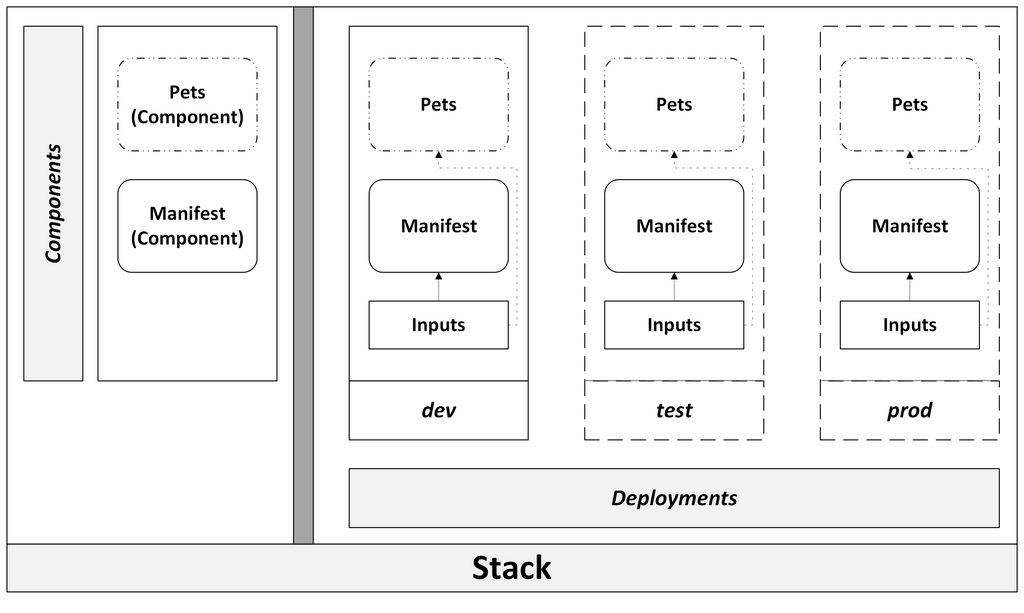

The diagram shows the Stack you will configure in this tutorial. You will create your Stack with a single `manifest` component deployed to a single `dev` environment. Next, you will add `test` and `prod` deployments to your Stack. Then you will add a new component and apply it to all deployments.

## Create example repository

Navigate to the [template repository](https://github.com/hashicorp-education/learn-terraform-stacks-concepts) for this tutorial. Click the **Use this template** button and select **Create a new repository**. Choose a GitHub account to create the repository in and name the new repository `learn-terraform-stacks-concepts`. Leave the rest of the settings at their default values.

In your terminal, clone your example repository, replacing `USER` with your own GitHub username.

```
$ git clone https://github.com/USER/learn-terraform-stacks-concepts
```

Change to the repository directory.

```
$ cd learn-terraform-stacks-concepts
```

The repository directory contains the Terraform modules you will use to create your Stack's components, a `.terraform-version` file, numbered directories containing the final configuration for each step, and a `.gitignore` file. The `.terraform-version` file configures HCP Terraform to use the specified Terraform version to manage your Stack's infrastructure. HCP Terraform requires `.terraform-version` to run.

## Create Stack configuration

Tip

If you prefer to skip this step, you may copy the contents of `02-basic-configuration` to your `learn-terraform-stacks-concepts` directory and continue with Create and deploy Stack in HCP Terraform.

Create and open a new file named `components.tfcomponent.hcl` in your editor. Then, paste the following configuration into the file to define the first component in your Stack.

components.tfcomponent.hcl

```
required_providers {
  time = {
    source  = "hashicorp/time"
    version = "~> 0.13.1"
  }
}

provider "time" "this" {}

component "manifest" {
  source = "./modules/manifest-module"

  inputs = {
    parent_directory = var.parent_directory
    environment_name = var.environment_name
  }

  providers = {
    time = provider.time.this
  }
}
```

A Stacks `component` block uses a Terraform module as a source, sets any variable values for the module in the `inputs` argument, and specifies the providers Terraform will use to provision your infrastructure in the `providers` argument.

In this example, the component uses a local module that creates a timestamped manifest for the environment. The module inputs are set by two variables which you will create in the next step, `parent_directory` and `environment_name`.

Next, create and open a new file named `variables.tfcomponent.hcl`. Then, paste the following configuration into the file to define the variables you used in `components.tfcomponent.hcl`.

variables.tfcomponent.hcl

```
variable "parent_directory" {
  description = "Parent directory environment directories are placed within"
  type        = string
  default     = "stacks_tutorial"
}

variable "environment_name" {
  description = "Environment to deploy"
  type        = string
  default     = "DEFAULT_TARGET"
}
```

Each deployment in your Stack can customize the behavior of your components by setting values for these variables. Just as with Terraform modules, variables without a default value are required. For more information on variables, refer to Use input variables to add module arguments.

Create and open a new file named `outputs.tfcomponent.hcl`. Then, paste the following configuration into the file to define the outputs from your Stack.

outputs.tfcomponent.hcl

```
output "manifest_filename" {
  description = "Manifest filename"
  value       = component.manifest.manifest_filename
  type        = string
}

output "manifest_contents" {
  description = "Contents of manifest file"
  value       = component.manifest.manifest_contents
  type        = string
}

output "simulated_filesystem" {
  description = "What the filesystem would look like"
  value       = concat([component.manifest.manifest_filename])
  type        = list(string)
}
```

Your Stack will output these values after applying the configuration. Practitioners deploying the Stack can use the output values, or pass them to other Stacks configurations or automation tools.

The three `.tfcomponent.hcl` files define the components, associated variables, and outputs that HCP Terraform manages for each of your stack's deployments.

Next, create and open a new file named `deployments.tfdeploy.hcl`. Paste the following configuration into the file to define your `dev` deployment.

deployments.tfdeploy.hcl

```
deployment "dev" {
  inputs = {
    environment_name = "dev"
  }
}
```

Every deployment is made up of all the components specified in your Stack. Define a deployment with the `deployment` block in a file ending with `.tfdeploy.hcl`, customized with the `inputs` argument.

This deployment file specifies one deployment, which is customized with `environment_name = "dev"`. Because `parent_directory` is not set in the `inputs` argument, HCP Terraform will use the default variable value for `parent_directory` defined in `variables.tfcomponent.hcl`.

In your terminal, initialize your Stack configuration.

```
$ terraform stacks init
Provider "hashicorp/time" is new and will be locked.
Downloading "hashicorp/time"@"0.13.1"....
Success! Configuration has been initialized and more commands can now be executed.
```

Terraform downloads the providers required by your Stack and creates a `.terraform.lock.hcl` file.

Format and validate your Stack configuration.

```
$ terraform stacks fmt
$ terraform stacks validate
.
Success! Terraform Stacks configuration is valid and ready for use within HCP Terraform.
```

Once you have created a valid Stack configuration, commit and push the configuration to your GitHub repository:

```
$ git add components.tfcomponent.hcl variables.tfcomponent.hcl deployments.tfdeploy.hcl outputs.tfcomponent.hcl .terraform.lock.hcl
$ git commit -m "Create initial Stack configuration"
$ git push
```

If you got stuck at any point during this step, refer to the `02-basic-configuration` directory in the repository to see the code implemented for this step.

## Create and deploy Stack in HCP Terraform

Navigate to [HCP Terraform](https://app.terraform.io) and select the organization you wish to use for this tutorial.

Next, ensure that Stacks is enabled for your organization by navigating to **Settings > General**. Ensure that the box next to `Stacks` is checked, and click the **Update organization** button.

Then navigate to **Projects**, click the **+ New Project** button, name your project `Learn Stacks`, and click the **Create** button to create it.

Now, complete the following steps to create your Stack within your project:

1. Click the **Create a stack** link.
2. Select **Version control workflow**, then click **Next**.
3. Choose your GitHub account from the list.
4. Select the repository containing the example Stack for this tutorial, `learn-terraform-stacks-concepts` and click **Next.**
5. Click **Create Stack** to finish creating your Stack.

HCP Terraform loads your Stack configuration from your VCS repository. This process may take a few moments to complete.

Once HCP Terraform loads your configuration, it plans your changes.

Click on **dev** in the **Deployment name** column to review the changes to be applied. Then, click the **Approve plan** button to apply it now.

Expand the **Outputs** details. HCP Terraform lists the outputs produced by your Stack. The timestamp in `manifest_contents` is a static value that will stay the same across subsequent changes to the `dev` deployment.

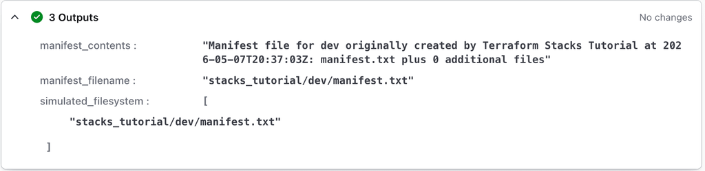

## Add new deployments

Now, you will add two new deployments to your Stack.

Open the `deployments.tfdeploy.hcl` file in your editor and add two new deployment blocks:

deployments.tfdeploy.hcl

```
deployment "test" {
  inputs = {
    environment_name = "test"
  }
}

deployment "prod" {
  inputs = {
    environment_name = "prod"
  }
}
```

Commit and push this change to your GitHub repository:

```
$ git add deployments.tfdeploy.hcl
$ git commit -m "Add test and prod deployments"
$ git push
```

Navigate to your Stack's **Configurations** page. HCP Terraform automatically started a new deployment run when you pushed your changes to your git repository. Click on the new deployment run under **Recent versions** if it is not already selected.

Under **Deployment runs**, HCP Terraform lists your `dev`, `test`, and `prod` deployments, as well as the current status of each. HCP Terraform plans changes to each deployment separately, and you can choose when to apply each plan.

Once HCP Terraform loads your new configuration, it automatically applies the change to your `dev` deployment, because there are no changes that affect it. HCP Terraform shows the new `test` and `prod` deployments as `Pending approval`.

Complete the following steps to deploy the `test` and `prod` environments:

1. Click the **...** button for `test` and select **Approve all plans**.
2. Click **Approve** to confirm your approval when prompted.
3. Click the **...** button for `prod` and select **Approve all plans**.
4. Click **Approve** to confirm your approval when prompted.

HCP Terraform deploys the new `test` and `prod` environments in parallel.

The existing `dev` environment was not affected by the change. To verify HCP Terraform did not change `dev`, click on `dev`. Expand the plan details by clicking **View plan details** and note that HCP Terraform shows `No changes` to the plan. HCP Terraform also shows that the plan was auto-approved, with a comment `Auto-approval orchestrated by rule empty_plan`. Examine the outputs and note they are unchanged.

After HCP Terraform successfully applies the `test` and `prod` environments, navigate to each environment and examine the outputs. Note each environment has a different timestamp in the `manifest_contents` output.

At this point, you have deployed your Stack to multiple environments from a single configuration. HCP Terraform manages each deployment independently, but you define them in one place.

If you got stuck at any point during this step, refer to the `03-add-deployments` directory in the repository to see the configuration implemented for this step.

## Add a component

Now, add a component to your Stack. The new component will use the `pet-module` module as its configuration source.

Open the `modules/pet-module/main.tf` file in your editor.

```
resource "random_pet" "pet" {
  count  = var.pet_count
  length = 3
}
```

The `pet-module` defines a `random_pet` resource, which is provided by the `hashicorp/random` provider.

```
 required_providers {
   random = {
     source  = "hashicorp/random"
     version = "~> 3.8.1"
   }

   time = {
     source  = "hashicorp/time"
     version = "~> 0.13.1"
   }
 }

 provider "random" "this" {}
 component "pets" {
   source = "./modules/pet-module"
   inputs = {
     environment_name = var.environment_name
     parent_directory = var.parent_directory
     pet_count        = var.pet_count
   }

   providers = {
     random = provider.random.this
   }
 }
```

Update the `inputs` block of the `manifest` component to refer to the filenames produced by the `pets` component:

```
component "manifest" {
  source = "./modules/manifest-module"

   inputs = {
     parent_directory = var.parent_directory
     environment_name = var.environment_name
     additional_files = component.pets.pet_filenames
   }

  providers = {
    time = provider.time.this
  }
}
```

```
 variable "pet_count" {
   description = "Number of pets to create"
   type        = number
   default     = 1
 }
```

Open the `deployments.tfdeploy.hcl` file in your editor, and set the `pet_count` value for the `test` and `prod` deployments:

deployments.tfdeploy.hcl

```
 deployment "test" {
   inputs = {
     environment_name = "test"
     pet_count        = 4
   }
 }

 deployment "prod" {
   inputs = {
     environment_name = "prod"
     pet_count        = 2
   }
 }
```

```
 output "simulated_filesystem" {
   description = "What the filesystem would look like"
   value       = concat([component.manifest.manifest_filename], component.pets.pet_filenames)
   type        = list(string)
 }
```

After you update your configuration, run `terraform stacks init` to download the added provider and update the lockfile. Then, format and validate the configuration:

```
$ terraform stacks fmt
$ terraform stacks validate
.
Success! Terraform Stacks configuration is valid and ready for use within HCP Terraform.
```

Next, commit and push this change to your GitHub repository:

```
$ git add components.tfcomponent.hcl variables.tfcomponent.hcl deployments.tfdeploy.hcl outputs.tfcomponent.hcl .terraform.lock.hcl
$ git commit -m "Add new pets component"
$ git push
```

Return to your Stack in HCP Terraform and navigate to your Stack's **Configurations** page. Once HCP Terraform loads your configuration change, it shows all three deployments as `Pending approval`.

Navigate into your `dev` deployment where HCP Terraform shows the pending plan details. The configuration changes you pushed adds the `pets` component and changes two of the three output values.

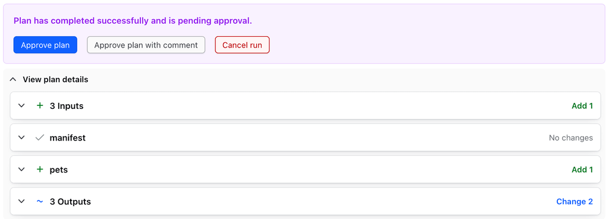

Return to your Stack's Configurations page and complete the following steps to deploy your changes:

1. Click the **...** button for `dev` and select **Approve all plans**.
2. Click **Approve** to confirm your approval when prompted.
3. Click the **...** button for `test` and select **Approve all plans**.
4. Click **Approve** to confirm your approval when prompted.
5. Click the **...** button for `prod` and select **Approve all plans**.
6. Click **Approve** to confirm your approval when prompted.

HCP Terraform applies changes to all three environments in parallel. In practice, you would likely apply changes to a single environment and confirm the change worked as expected before applying changes to multiple environments.

Navigate to your `dev` deployment and examine the changes to the outputs. Your deployment added one new file to the `simulated_filesystem` output, because the default `pet_count` defined in `variables.tfcomponent.hcl` is `1`, and `pet_count` is not set for the dev deployment in `deployments.tfdeploy.hcl`.

Navigate into your `test` environment and examine the changes to the outputs. Your deployment added four new files to the `simulated_filesystem` output, because `pet_count`is set to `4` in the test deployment in `deployments.tfdeploy.hcl`.

In this step, you added a component to all of your deployments at the same time, with different parameters for each deployment.

If you got stuck at any point during this step, refer to the `04-add-component` directory in the repository to see the code implemented for this step.

## Modify single deployment

Now, you will change an input for a single deployment.

Open the `deployments.tfdeploy.hcl` file in your editor, and add the following line to your `dev` deployment `inputs` block:

deployments.tfdeploy.hcl

```
deployment "dev" {
  inputs = {
    environment_name = "dev"
    parent_directory = "non_default_directory"
  }
}

# ...
```

Next, commit and push this change to your GitHub repository:

```
$ git add deployments.tfdeploy.hcl
$ git commit -m "Change parent directory for dev"
$ git push
```

Return to your Stack in HCP Terraform and navigate to your Stack's **Configurations** page. Once HCP Terraform loads your configuration change, it automatically plans the change to all three deployments.

HCP Terraform automatically applies the update to the `test` and `prod` environments because the change does not affect either environment. To verify HCP Terraform did not create, destroy, or modify any resources in either of these environments, click on the name of the environment. Examine the plans and outputs and note they are unchanged.

HCP Terraform also automatically applies the update to the `dev` deployment because the plan did not create, update, or destroy any resources. The plan only changed outputs.

Navigate to your `dev` deployment. Expand the **Outputs** details. The change to the `parent_directory` input caused both the `manifest_filename` and `simulated_filesystem` outputs to change.

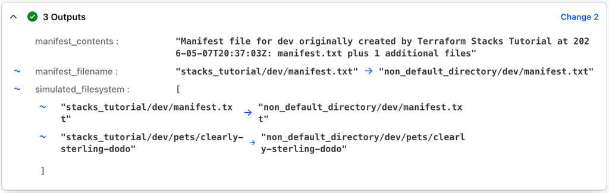

In this step, you updated a single deployment, leaving others unchanged.

If you got stuck at any point during this step, refer to the `05-modify-deployment` directory in the repository to see the code implemented for this step.

## Destroy infrastructure

Now you have used a Terraform Stack to deploy three independent environments using a single Stack definition, added a component, and modified a single deployment.

Before finishing this tutorial, destroy your infrastructure.

### Destroy deployments

To destroy a deployment, set that deployment's `destroy` argument to `true` and commit your configuration to your VCS. Destroy all three of the deployments you created in this tutorial.

Open `deployments.tfdeploy.hcl` and add `destroy = true` to each deployment:

deployments.tfdeploy.hcl

[output not shown]

Commit and push this change to your GitHub repository:

```
$ git add deployments.tfdeploy.hcl
$ git commit -m "Destroy all deployments"
$ git push
```

Return to your Stack in HCP Terraform and navigate to your Stack's **Deployments page**. Once HCP Terraform loads your configuration change, it creates a plan to destroy all three of your deployments. Navigate to each deployment and click the **Approve plan** button to destroy the resources for that deployment.

To verify that the virtual infrastructure created for a deployment was destroyed, navigate to the deployment. Notice that HCP Terraform removed the **Output** details. Click the **View state** button and observe that the state is now empty.

If you got stuck at any point during this step, refer to the `06-destroy` directory in the repository to see the configuration implemented for this step.

### Delete stack

Once you have destroyed all three of your deployments, navigate to your Stack's **Settings > Destruction and Deletion** page, and click the **Delete** button. Confirm the action, and click the **Delete** button.

## Next steps

In this tutorial, you created virtual infrastructure in three environments using Terraform Stacks. You learned how the Stacks concepts of components and deployments build upon the traditional Terraform concepts of modules and workspaces, how to add a component to a Stack, how to apply changes to multiple environments in parallel with Stacks, and how to configure environments independently.

To learn more about Stacks, refer to the following resources:

- Study the `*.tfdeploy.hcl` and `*.tfcomponent.hcl` files in this tutorial to understand how Stacks components, deployments, variables, and outputs fit together
- Follow the Deploy a Stack tutorial to deploy real infrastructure to AWS, Azure, or GCP
- Review Stacks concepts by reading the [Terraform Stacks, explained](https://www.hashicorp.com/en/blog/terraform-stacks-explained) blog post
- Read the [Stacks documentation](https://developer.hashicorp.com/terraform/cloud-docs/stacks)
- Read the Stacks Use Cases documentation